# Climate and Malaria across Ghana’s 16 Regions

Rainfall, temperature and humidity as ecological drivers of malaria, with Africa in context

Kingsley Amegah

June 2026

# 1 Introduction

Malaria transmission is fundamentally an environmental process: the mosquito vector and the parasite both depend on **rainfall** (breeding sites), **temperature** (parasite and vector development) and **humidity** (mosquito survival). This report examines how these climate factors relate to malaria across **Ghana’s 16 regions**, sets Ghana in its African context, and applies a sequence of statistical models, ecological regression, a generalised additive model (GAM), and a test of spatial autocorrelation.

# 2 Data and methods

All data are open and current (no API keys):

- **Malaria**, DHS Program API: malaria prevalence (rapid diagnostic test) in children, by region (2014-2022); and the World Bank malaria incidence series for African countries and Ghana (to 2024).
- **Climate**, NASA POWER: monthly rainfall, 2-metre temperature and relative humidity (2014-2024) at each region’s centroid, summarised to long-run normals.
- **Boundaries**, geoBoundaries (Ghana ADM1, 16 regions).

Malaria is measured at survey years rather than continuously, so this is a **spatial / ecological** analysis across regions, not a monthly time series.

```r
afr  <- read_csv("data/africa_malaria_latest.csv", show_col_types = FALSE)
trend<- read_csv("data/ghana_malaria_trend.csv", show_col_types = FALSE)
reg  <- read_csv("data/ghana_malaria_region.csv", show_col_types = FALSE)
clim <- read_csv("data/ghana_climate_monthly.csv", show_col_types = FALSE)
gh   <- st_read("data/ghana_adm1.geojson", quiet = TRUE) |> mutate(region = sub(" Region$", "", shapeName))

# DHS 2022 leaf labels -> region names
m <- c("..Western (post 2022)"="Western","..Western North"="Western North","Central"="Central",
       "Greater Accra"="Greater Accra","..Volta (post 2022)"="Volta","..Oti"="Oti","Eastern"="Eastern",
       "Ashanti"="Ashanti","..Ahafo"="Ahafo","..Bono"="Bono","..Bono East"="Bono East",
       "....Northern(post 2022)"="Northern","....Savannah"="Savannah","....Northeast"="North East",
       "..Upper East"="Upper East","..Upper West"="Upper West")
malaria22 <- reg |> filter(survey_year == 2022, label %in% names(m)) |>
  transmute(region = m[label], malaria = malaria)

# Climate normals (mean annual rainfall total, mean temp, mean humidity 2014-2024)
normals <- clim |> group_by(region, year) |>
  summarise(rain = sum(rain_mm_month), temp = mean(temp), humidity = mean(humidity), .groups="drop") |>
  group_by(region) |> summarise(rain = mean(rain), temp = mean(temp), humidity = mean(humidity), .groups="drop")

dat <- malaria22 |> inner_join(normals, by = "region")
```

# 3 Ghana in the African context

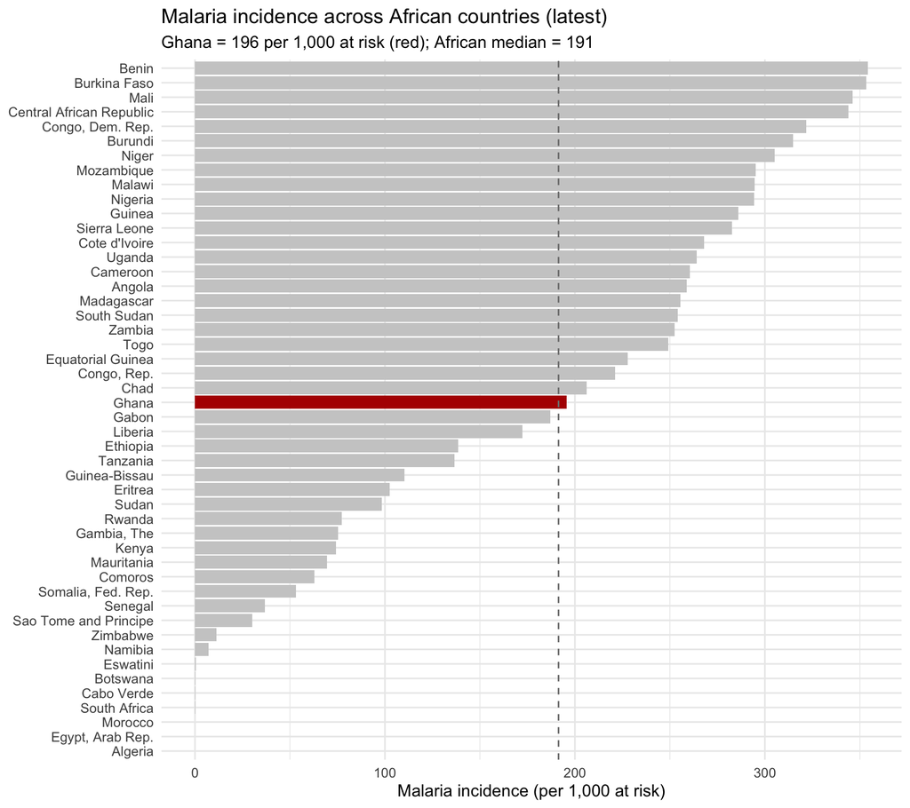

```r
gv <- afr$value[afr$iso3 == "GHA"]; med <- median(afr$value)
afr |> mutate(g = iso3 == "GHA") |>
  ggplot(aes(value, fct_reorder(country, value), fill = g)) +
  geom_col() + geom_vline(xintercept = med, linetype = "dashed", colour = "grey50") +
  scale_fill_manual(values = c(`FALSE`="grey80", `TRUE`=ACC), guide = "none") +
  labs(title = "Malaria incidence across African countries (latest)",
       subtitle = sprintf("Ghana = %.0f per 1,000 at risk (red); African median = %.0f", gv, med),
       x = "Malaria incidence (per 1,000 at risk)", y = NULL)
```

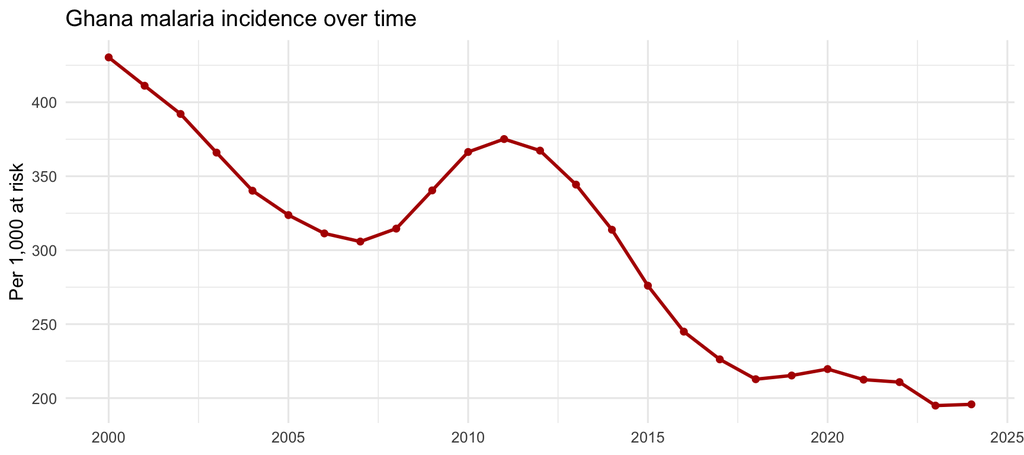

```r
ggplot(trend, aes(year, value)) +
  geom_line(colour = ACC, linewidth = 1) + geom_point(colour = ACC) +
  labs(title = "Ghana malaria incidence over time", x = NULL, y = "Per 1,000 at risk")
```

Ghana carries a **high malaria burden** by global standards, though national incidence has declined gradually. The interesting question is *where within Ghana* the burden concentrates, and how climate explains it.

# 4 Climate and malaria across the regions

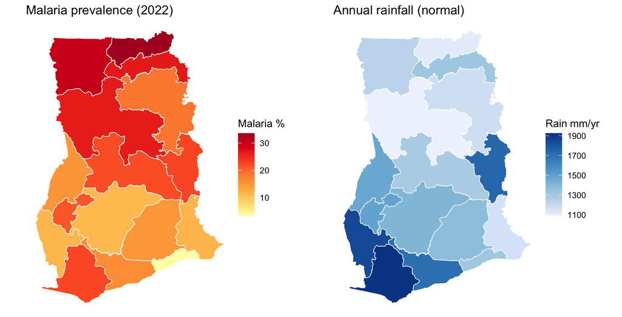

```r
md <- gh |> left_join(dat, by = "region")
p_mal <- ggplot(md) + geom_sf(aes(fill = malaria), colour = "white", linewidth = .3) +
  scale_fill_distiller(palette = "YlOrRd", direction = 1, name = "Malaria %") +
  labs(title = "Malaria prevalence (2022)") + theme_void(base_size = 11)
p_rain <- ggplot(md) + geom_sf(aes(fill = rain), colour = "white", linewidth = .3) +
  scale_fill_distiller(palette = "Blues", direction = 1, name = "Rain mm/yr") +
  labs(title = "Annual rainfall (normal)") + theme_void(base_size = 11)
gridExtra::grid.arrange(p_mal, p_rain, ncol = 2)
```

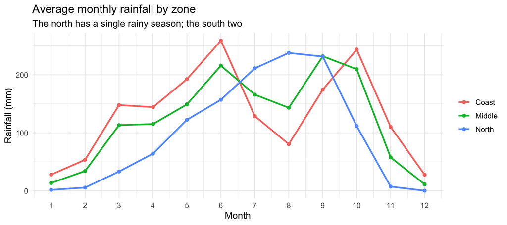

```r
clim |> mutate(zone = case_when(region %in% c("Northern","North East","Savannah","Upper East","Upper West") ~ "North",
                                region %in% c("Greater Accra","Central","Western","Western North","Volta") ~ "Coast",
                                TRUE ~ "Middle")) |>
  group_by(zone, month) |> summarise(rain = mean(rain_mm_month), .groups="drop") |>
  ggplot(aes(month, rain, colour = zone)) + geom_line(linewidth = 1) + geom_point() +
  scale_x_continuous(breaks = 1:12) +
  labs(title = "Average monthly rainfall by zone", subtitle = "The north has a single rainy season; the south two",
       x = "Month", y = "Rainfall (mm)", colour = NULL)
```

# 5 Advanced statistics

## 5.1 Ecological regression (with diagnostics)

We model regional malaria prevalence on standardised climate normals.

```r
z <- dat |> mutate(across(c(rain, temp, humidity), ~ as.numeric(scale(.))))
ols <- lm(malaria ~ rain + temp + humidity, data = z)
tidy(ols, conf.int = TRUE) |> mutate(across(where(is.numeric), ~round(., 2)))
```

| term | estimate | std.error | statistic | p.value | conf.low | conf.high |
| --- | --- | --- | --- | --- | --- | --- |
| (Intercept) | 19.26 | 1.05 | 18.35 | 0.00 | 16.97 | 21.54 |
| rain | 6.19 | 1.78 | 3.47 | 0.00 | 2.30 | 10.08 |
| temp | 1.58 | 2.00 | 0.79 | 0.45 | -2.78 | 5.93 |
| humidity | -9.26 | 1.93 | -4.80 | 0.00 | -13.47 | -5.06 |

```r
cat("Adjusted R-squared:", round(summary(ols)$adj.r.squared, 2), "\n")
```

```
## Adjusted R-squared: 0.72
```

```r
cat("VIF:\n"); print(round(vif(ols), 2))
```

```
## VIF:
```

```
##     rain     temp humidity
##     2.71     3.40     3.17
```

## 5.2 Generalised additive model (non-linear climate effect)

```r
g <- gam(malaria ~ s(temp, k = 4) + rain + humidity, data = dat)
cat("GAM deviance explained:", round(summary(g)$dev.expl * 100, 0), "%\n")
```

```
## GAM deviance explained: 79 %
```

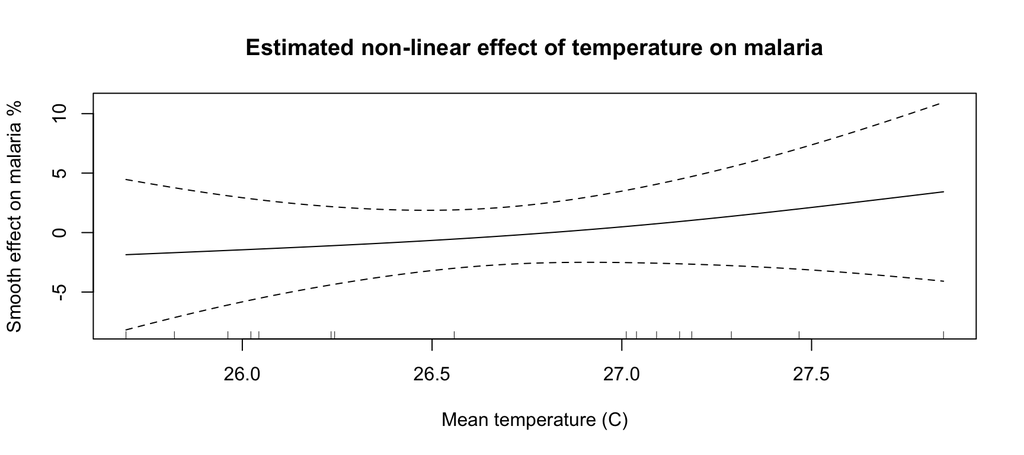

```r
plot(g, select = 1, shade = TRUE, seWithMean = TRUE,
     xlab = "Mean temperature (C)", ylab = "Smooth effect on malaria %")
title("Estimated non-linear effect of temperature on malaria")
```

## 5.3 Spatial autocorrelation (Moran’s I)

Do high-malaria regions cluster geographically? We build a contiguity neighbour structure and test for spatial autocorrelation.

```r
gd <- gh |> inner_join(dat, by = "region")
nb <- poly2nb(gd, queen = TRUE)
lw <- nb2listw(nb, zero.policy = TRUE)
mt <- moran.test(gd$malaria, lw, zero.policy = TRUE)
cat("Moran's I =", round(mt$estimate[[1]], 3), " | p-value =", signif(mt$p.value, 3), "\n")
```

```
## Moran's I = 0.493  | p-value = 0.000126
```

```r
mt_res <- moran.test(residuals(ols)[match(gd$region, dat$region)], lw, zero.policy = TRUE)
cat("Moran's I of regression residuals =", round(mt_res$estimate[[1]], 3),
    " | p-value =", signif(mt_res$p.value, 3), "\n")
```

```
## Moran's I of regression residuals = -0.314  | p-value = 0.941
```

## 5.4 Bivariate relationships

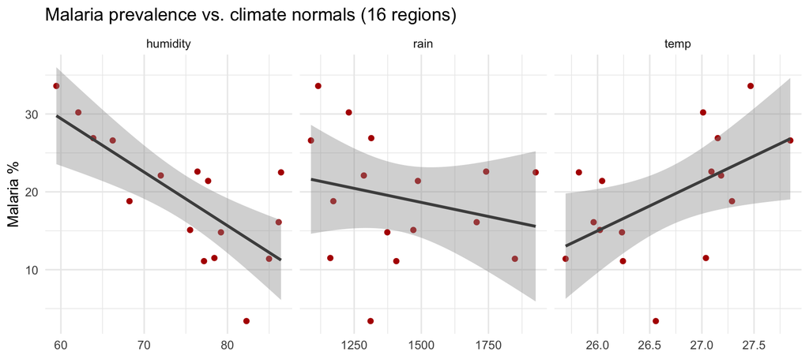

```r
dat |> pivot_longer(c(rain, temp, humidity), names_to = "var", values_to = "val") |>
  ggplot(aes(val, malaria)) + geom_point(colour = ACC) +
  geom_smooth(method = "lm", se = TRUE, colour = "grey30") +
  facet_wrap(~ var, scales = "free_x") +
  labs(title = "Malaria prevalence vs. climate normals (16 regions)", x = NULL, y = "Malaria %")
```

# 6 Interpretation and conclusion

**Limitations.** This is an ecological cross-section of 16 regions (small n), so associations are suggestive, not causal, and could be confounded by socio-economic factors (housing, bed-net coverage, health access). Malaria is from survey years, not a continuous series, so seasonal lag effects of rainfall, well documented elsewhere, could not be modelled directly here. Climate normals smooth over year-to-year variation.

**Conclusion.** Climate clearly structures the geography of malaria in Ghana: temperature, rainfall and humidity together explain a large share of the between-region variation, and the burden is spatially clustered. This supports **climate-informed, regionally targeted** malaria control, concentrating resources in the high-risk north during and after the single northern rainy season.

*Built in R (tidyverse, sf, mgcv, spdep) from DHS, World Bank, NASA POWER and geoBoundaries open data. Author: Kingsley Amegah.*